# Data Munging

LTC Cade Saie

October 26, 2015

cade.m.saie.mil@mail.mil

## Introduction

Data munging can can many things to many people but at the heart of the matter it is the act of cleaning data. It is talking data from one system, manipulating it, and then passing it to another. This is the aspect of manipulating raw data to achieve a final form. Many times we spend a lot of our time looking for data only to find it and then realize how much work is still in front of us. It is beleived that analysts will spend up to 80% of their time on the process of cleaning and preparing the data (Dasu and Johnson 2003). Many people can and will attribute to this statement. It is also beleived that much of the data (up to 90%) was created in the last 2-3 years, which means we have a huge amount of data to look at….and clean. So where do we go from here? Many people try to still do this with tools like EXCEL, but that hourglass spinning keeps coming back everytime you ask it to do to much, which is usually what you need it to do.

## What can we do?

Many people will tell you most sucessful ORSAs know how to program. In fact one the smartmest men I ever worked for as an ORSA told me if you plan on doing it more than one time, you need to write a program to do it. So what can we use? We primarly will be discussing R but the bottom line is you can use whatever you works best for you. What we are looking to do is make the data suitable for processing for another use such as a model, mathematical function, or a vizualization. Ultimately, this will lead to revealing information and/or insights that were not apparent from the data in its original form. This is a core competency of the FA49 Officer and data scientists.

> The Operations Research/Systems Analysis FA provides uniquely skilled officers that assist decision makers in solving complex problems by producing the analysis and logical reasoning necessary to inform and underpin critical decisions. [AR 600-3](http://www.apd.army.mil/pdffiles/p600_3.pdf)

> Data scientists use their data and analytical ability to find and interpret rich data sources; manage large amounts of data despite hardware, software, and bandwidth constraints; merge data sources; ensure consistency of datasets; create visualizations to aid in understanding data; build mathematical models using the data; and present and communicate the data insights/findings. They are often expected to produce answers in days rather than months, work by exploratory analysis and rapid iteration, and to get/present results with dashboards (displays of current values) rather than papers/reports, as statisticians normally do. [Wikipedia](https://en.wikipedia.org/wiki/Data_science)

knitr::opts_chunk$set(warning=FALSE)

## R Tools for data munging

[TED Talks about data](https://www.ted.com/talks/hans_rosling_shows_the_best_stats_you_ve_ever_seen)

R has many tools for this, with many of them developed by [Hadley Wickham](https://github.com/hadley/), one of the premeire developers for R Studio. The two we will be focusing on will be

1. tidyr
2. dplyr

### tidyr

```r
library(tidyr)
```

The concept behind this is simple, tidy your data. This means each column is a variable and each row is an observation to complement R’s vectorized operations. The four fundamental functions of tidy data are:

- `gather()` takes multiple columns, and gathers them into key-value pairs: it makes “wide” data longer
- `spread()` takes two columns (key & value) and spreads in to multiple columns, it makes “long” data wider
- `separate()` splits a single column into multiple columns
- `unite()` combines multiple columns into a single column

### gather() function

*Objective:* Reshaping a wide format data set to a long format data set

*Description:* There are times when our data is considered unstacked and a common attribute of concern is spread out across columns. To reformat the data such that these common attributes are gathered together as a single variable, the gather() function will take multiple columns and collapse them into key-value pairs, duplicating all other columns as needed.

*Complement to:* `spread()`

#### *Example*

We create some data

```r
stocks <- data.frame(             #Store in a data frame called stocks
     time = as.Date('2009-01-01') + 0:9,   # create a variable named time and make 10 entries
     X = rnorm(10, 0, 1), #10 normally distributed variables with a mean of 0 and Std Dev of 1
     Y = rnorm(10, 0, 2), #10 normally distributed variables with a mean of 0 and Std Dev of 2
     Z = rnorm(10, 0, 4))  #10 normally distributed variables with a mean of 0 and Std Dev of 4
stocks
```

```
##          time          X           Y          Z
## 1  2009-01-01  1.6153039 -0.08945915  8.0267913
## 2  2009-01-02  0.1697393 -1.47463909 -5.3509129
## 3  2009-01-03 -0.1982478  1.10361992 -6.4173390
## 4  2009-01-04 -0.6205937  0.32303182 -2.1135281
## 5  2009-01-05  0.4988870  0.63304718  2.3831248
## 6  2009-01-06 -0.5712398 -1.14404647 -0.9287297
## 7  2009-01-07 -0.6136208 -2.10409049 -3.8254461
## 8  2009-01-08 -0.6122456  1.26317571 12.1700518
## 9  2009-01-09  2.1242290 -0.48627519 -4.9065614
## 10 2009-01-10 -0.1324669 -0.06652490  2.1004767
```

the terms for `gather()` are `gather(data, key, value, ..., na.rm = FALSE, convert = FALSE)`

```r
df<-gather(stocks, stock, price, -time)  #gather from the stocks df, by stock and price, excluding time
df
```

```
##          time stock       price
## 1  2009-01-01     X  1.61530395
## 2  2009-01-02     X  0.16973930
## 3  2009-01-03     X -0.19824779
## 4  2009-01-04     X -0.62059371
## 5  2009-01-05     X  0.49888698
## 6  2009-01-06     X -0.57123981
## 7  2009-01-07     X -0.61362077
## 8  2009-01-08     X -0.61224559
## 9  2009-01-09     X  2.12422903
## 10 2009-01-10     X -0.13246692
## 11 2009-01-01     Y -0.08945915
## 12 2009-01-02     Y -1.47463909
## 13 2009-01-03     Y  1.10361992
## 14 2009-01-04     Y  0.32303182
```

[output cut: 16 more lines]

### separate( ) function:

*Objective:* Splitting a single variable into two

*Description:* Many times a single column variable will capture multiple variables, or even parts of a variable you just don’t care about. In each of these cases, our objective may be to separate characters within the variable string. This can be accomplished using the separate() function which turns a single character column into multiple columns.

*Complement to:* unite()

#### *Example*

We will use the previous data frame `df` and the terms are `separate(data, col, into, sep = " ", remove = TRUE, convert = FALSE)`. Lets say we want to break the time column in to Year, Month, and Day…

```r
df2<-separate(df, time, c('Year', 'Month', 'Day'),sep="-")
df2
```

```
##    Year Month Day stock       price
## 1  2009    01  01     X  1.61530395
## 2  2009    01  02     X  0.16973930
## 3  2009    01  03     X -0.19824779
## 4  2009    01  04     X -0.62059371
## 5  2009    01  05     X  0.49888698
## 6  2009    01  06     X -0.57123981
## 7  2009    01  07     X -0.61362077
## 8  2009    01  08     X -0.61224559
## 9  2009    01  09     X  2.12422903
## 10 2009    01  10     X -0.13246692
## 11 2009    01  01     Y -0.08945915
## 12 2009    01  02     Y -1.47463909
## 13 2009    01  03     Y  1.10361992
## 14 2009    01  04     Y  0.32303182
```

[output cut: 16 more lines]

So we can see that we separated the df data frame time column, by extracting the year, month, and day.

### unite( ) function:

*Objective:* Merging two variables into one

*Description:* There may be a time in which we would like to combine the values of two variables. The unite() function is a convenience function to paste together multiple variable values into one. In essence, it combines two variables of a single observation into one variable.

*Complement to:* separate()

#### *Example*

We will use the previous data frame `df2` and the terms are `unite(data, col, ..., sep = " ", remove = TRUE)`. Lets say we want to re-unite the time columm but want to change it Originally we had YYYY-MM-DD and we want MM/DD/YYYY now.

```r
df3<-unite(df2, Date, c(Month, Day, Year), sep="/")
df3
```

```
##          Date stock       price
## 1  01/01/2009     X  1.61530395
## 2  01/02/2009     X  0.16973930
## 3  01/03/2009     X -0.19824779
## 4  01/04/2009     X -0.62059371
## 5  01/05/2009     X  0.49888698
## 6  01/06/2009     X -0.57123981
## 7  01/07/2009     X -0.61362077
## 8  01/08/2009     X -0.61224559
## 9  01/09/2009     X  2.12422903
## 10 01/10/2009     X -0.13246692
## 11 01/01/2009     Y -0.08945915
## 12 01/02/2009     Y -1.47463909
## 13 01/03/2009     Y  1.10361992
## 14 01/04/2009     Y  0.32303182
```

[output cut: 16 more lines]

So we can see that we re-united the time column, renamed it Date, and changed the date format.

### spread( ) function:

*Objective:* Reshaping long format to wide format

*Description:* There are times when we are required to turn long formatted data into wide formatted data. The spread() function spreads a key-value pair across multiple columns.

*Complement to:* gather()

#### *Example*

We will use the previous data frame `df3` and the terms are `spread(data, key, value, fill = NA, convert = FALSE)`. Lets say we want to go back to the first format where each row corresponds to the date.

```r
spread(df3, stock, price)
```

```
##          Date          X           Y          Z
## 1  01/01/2009  1.6153039 -0.08945915  8.0267913
## 2  01/02/2009  0.1697393 -1.47463909 -5.3509129
## 3  01/03/2009 -0.1982478  1.10361992 -6.4173390
## 4  01/04/2009 -0.6205937  0.32303182 -2.1135281
## 5  01/05/2009  0.4988870  0.63304718  2.3831248
## 6  01/06/2009 -0.5712398 -1.14404647 -0.9287297
## 7  01/07/2009 -0.6136208 -2.10409049 -3.8254461
## 8  01/08/2009 -0.6122456  1.26317571 12.1700518
## 9  01/09/2009  2.1242290 -0.48627519 -4.9065614
## 10 01/10/2009 -0.1324669 -0.06652490  2.1004767
```

So we can see that we are back to the original format with the modified date format.

### dplyr Operations

```r
library(dplyr)
```

There are seven fundamental functions of data transformation using dplyr, they are:

- `select()` selecting variables
- `filter()` provides basic filtering capabilities
- `group_by()` groups data by categorical levels
- `summarise()` summarise data by functions of choice
- `arrange()` ordering data
- `join()` joining separate dataframes
- `mutate()` create new variables

### select( ) function:

*Objective:* Reduce dataframe size to only desired variables for current task

*Description:* When working with a sizable dataframe, often we desire to only assess specific variables. The select() function allows you to select and/or rename variables.

#### *Example*

We will use the previous data frame from the World Bank API `WBDAta` and the terms are `select(data, ...)` and some special functions. * `starts_with(x, ignore.case = TRUE)`: names starts with x * `ends_with(x, ignore.case = TRUE)`: names ends in x * `contains(x, ignore.case = TRUE)`: selects all variables whose name contains x * `matches(x, ignore.case = TRUE)`: selects all variables whose name matches the regular expression x

Lets extract just the country name and lat/long

```r
library(WDI)
fiveeyes<-c("AU","CA","GB","US","NZ")
WBData <- WDI(country = fiveeyes, indicator = "NY.GNS.ICTR.GN.ZS",start = 2010, end = 2014, extra = TRUE, cache = NULL)
df4<-select(WBData,country,longitude, latitude)
df4
```

```
##           country longitude latitude
## 1       Australia   149.129  -35.282
## 2       Australia   149.129  -35.282
## 3       Australia   149.129  -35.282
## 4       Australia   149.129  -35.282
## 5       Australia   149.129  -35.282
## 6          Canada  -75.6919  45.4215
## 7          Canada  -75.6919  45.4215
## 8          Canada  -75.6919  45.4215
## 9          Canada  -75.6919  45.4215
## 10         Canada  -75.6919  45.4215
## 11 United Kingdom -0.126236  51.5002
## 12 United Kingdom -0.126236  51.5002
## 13 United Kingdom -0.126236  51.5002
## 14 United Kingdom -0.126236  51.5002
## 15 United Kingdom -0.126236  51.5002
## 16    New Zealand   174.776 -41.2865
## 17    New Zealand   174.776 -41.2865
## 18    New Zealand   174.776 -41.2865
## 19    New Zealand   174.776 -41.2865
## 20    New Zealand   174.776 -41.2865
## 21  United States   -77.032  38.8895
## 22  United States   -77.032  38.8895
## 23  United States   -77.032  38.8895
## 24  United States   -77.032  38.8895
## 25  United States   -77.032  38.8895
```

we can see there are duplicates

```r
countries<-unique(df4)
```

### filter( ) function:

*Objective:* Reduce rows/observations with matching conditions

*Description:* Filtering data is a common task to identify/select observations in which a particular variable matches a specific value/condition. The `filter()` function provides this capability.

#### *Example*

We will use the previous data frame from the World Bank API `WBDAta` and the terms are `filter(data, ...)` and some special functions.

- `starts_with(x, ignore.case = TRUE)`: names starts with x
- `ends_with(x, ignore.case = TRUE)`: names ends in x
- `contains(x, ignore.case = TRUE)`: selects all variables whose name contains x
- `matches(x, ignore.case = TRUE)`: selects all variables whose name matches the regular expression x

There are multiple logic rules for the `filter()` function such as:

- `<` Less than
- `>` Greater than
- `==` Equal to
- `<=` Less than or equal to
- `>=` Greater than or equal to
- `!=` Not equal to
- `%in%` Group membership
- `is.na` is NA
- `!is.na` is not NA
- `&,|,!` Boolean operators

Lets use the `WBData` data frame again and filter using the year and indicator

```r
filter(WBData,year==2012) #year=2012
```

```
##   iso2c        country NY.GNS.ICTR.GN.ZS year iso3c
## 1    AU      Australia          25.98642 2012   AUS
## 2    CA         Canada          21.44299 2012   CAN
## 3    GB United Kingdom          12.80220 2012   GBR
## 4    NZ    New Zealand          18.48713 2012   NZL
## 5    US  United States          17.11288 2012   USA
##                                      region         capital longitude
## 1   East Asia & Pacific (all income levels)        Canberra   149.129
## 2                             North America          Ottawa  -75.6919
## 3 Europe & Central Asia (all income levels)          London -0.126236
## 4   East Asia & Pacific (all income levels)      Wellington   174.776
## 5                             North America Washington D.C.   -77.032
##   latitude            income        lending
## 1  -35.282 High income: OECD Not classified
## 2  45.4215 High income: OECD Not classified
## 3  51.5002 High income: OECD Not classified
## 4 -41.2865 High income: OECD Not classified
## 5  38.8895 High income: OECD Not classified
```

```r
filter(WBData,year!=2012) #year not equal to 2012
```

```
##    iso2c        country NY.GNS.ICTR.GN.ZS year iso3c
## 1     AU      Australia                NA 2014   AUS
## 2     AU      Australia          25.23537 2013   AUS
## 3     AU      Australia          25.02904 2011   AUS
## 4     AU      Australia          23.50377 2010   AUS
## 5     CA         Canada                NA 2014   CAN
## 6     CA         Canada          21.62395 2013   CAN
## 7     CA         Canada          21.29820 2011   CAN
## 8     CA         Canada          19.68389 2010   CAN
## 9     GB United Kingdom                NA 2014   GBR
## 10    GB United Kingdom          12.66874 2013   GBR
## 11    GB United Kingdom          14.55066 2011   GBR
## 12    GB United Kingdom          13.60192 2010   GBR
## 13    NZ    New Zealand                NA 2014   NZL
## 14    NZ    New Zealand          20.99939 2013   NZL
```

[output cut: 48 more lines]

```r
filter(WBData,NY.GNS.ICTR.GN.ZS>=20) #NY.GNS.ICTR.GN.ZS>=20
```

```
##   iso2c     country NY.GNS.ICTR.GN.ZS year iso3c
## 1    AU   Australia          25.23537 2013   AUS
## 2    AU   Australia          25.98642 2012   AUS
## 3    AU   Australia          25.02904 2011   AUS
## 4    AU   Australia          23.50377 2010   AUS
## 5    CA      Canada          21.62395 2013   CAN
## 6    CA      Canada          21.44299 2012   CAN
## 7    CA      Canada          21.29820 2011   CAN
## 8    NZ New Zealand          20.99939 2013   NZL
##                                    region    capital longitude latitude
## 1 East Asia & Pacific (all income levels)   Canberra   149.129  -35.282
## 2 East Asia & Pacific (all income levels)   Canberra   149.129  -35.282
## 3 East Asia & Pacific (all income levels)   Canberra   149.129  -35.282
## 4 East Asia & Pacific (all income levels)   Canberra   149.129  -35.282
## 5                           North America     Ottawa  -75.6919  45.4215
## 6                           North America     Ottawa  -75.6919  45.4215
## 7                           North America     Ottawa  -75.6919  45.4215
## 8 East Asia & Pacific (all income levels) Wellington   174.776 -41.2865
##              income        lending
## 1 High income: OECD Not classified
## 2 High income: OECD Not classified
## 3 High income: OECD Not classified
## 4 High income: OECD Not classified
## 5 High income: OECD Not classified
## 6 High income: OECD Not classified
## 7 High income: OECD Not classified
## 8 High income: OECD Not classified
```

```r
filter(WBData,NY.GNS.ICTR.GN.ZS>=20 & year>2012) #NY.GNS.ICTR.GN.ZS>=20 & year>=2012
```

```
##   iso2c     country NY.GNS.ICTR.GN.ZS year iso3c
## 1    AU   Australia          25.23537 2013   AUS
## 2    CA      Canada          21.62395 2013   CAN
## 3    NZ New Zealand          20.99939 2013   NZL
##                                    region    capital longitude latitude
## 1 East Asia & Pacific (all income levels)   Canberra   149.129  -35.282
## 2                           North America     Ottawa  -75.6919  45.4215
## 3 East Asia & Pacific (all income levels) Wellington   174.776 -41.2865
##              income        lending
## 1 High income: OECD Not classified
## 2 High income: OECD Not classified
## 3 High income: OECD Not classified
```

### group_by( ) function:

*Objective:* Group data by categorical variables

*Description:* Often, observations are nested within groups or categories and our goals is to perform statistical analysis both at the observation level and also at the group level. The `group_by()` function allows us to create these categorical groupings.

#### *Example*

We will use the previous data frame from the World Bank API `WBDAta` and the terms are `group_by(data, ...)`. For this we will group by year. THis is a silent function where no observable manipulation of the data is performed as a result of applying the function. Rather, the only change you’ll notice is, if you print the dataframe you will notice underneath the Source information and prior to the actual dataframe, an indicator of what variable the data is grouped by will be provided. The real magic of the group_by() function comes when we perform summary statistics which we will cover next.

```r
group_by(WBData,year)
```

```
## Source: local data frame [25 x 11]
## Groups: year [5]
##
##    iso2c   country NY.GNS.ICTR.GN.ZS  year  iso3c
##    (chr)     (chr)             (dbl) (dbl) (fctr)
## 1     AU Australia                NA  2014    AUS
## 2     AU Australia          25.23537  2013    AUS
## 3     AU Australia          25.98642  2012    AUS
## 4     AU Australia          25.02904  2011    AUS
## 5     AU Australia          23.50377  2010    AUS
## 6     CA    Canada                NA  2014    CAN
## 7     CA    Canada          21.62395  2013    CAN
## 8     CA    Canada          21.44299  2012    CAN
## 9     CA    Canada          21.29820  2011    CAN
## 10    CA    Canada          19.68389  2010    CAN
## ..   ...       ...               ...   ...    ...
## Variables not shown: region (fctr), capital (fctr), longitude (fctr),
##   latitude (fctr), income (fctr), lending (fctr)
```

### summarise( ) function:

*Objective:* Perform summary statistics on variables

*Description:* Obviously the goal of all this data wrangling is to be able to perform statistical analysis on our data. The `summarise()` or `summarize()` function allows us to perform the majority of the initial summary statistics when performing exploratory data analysis.

#### *Example*

We will use the previous data frame from the World Bank API `WBDAta` and the terms are `summarise(data, ...)`. First we will get the mean indicator value

```r
summarise(WBData,mean_ind= mean(NY.GNS.ICTR.GN.ZS))
```

```
##   mean_ind
## 1       NA
```

our answer is NA?

Well if we look at the data we see there are NA values for the year 2014. We can filter it out or use a base function

```r
WBData2<-na.omit(WBData)
```

lets try again

```r
summarise(WBData2,mean_ind= mean(NY.GNS.ICTR.GN.ZS))
```

```
##   mean_ind
## 1  18.9621
```

lets check out some more but here is another way to remove NAs

```r
summarise(WBData, Min = min(NY.GNS.ICTR.GN.ZS, na.rm=TRUE),
                  Median = median(NY.GNS.ICTR.GN.ZS, na.rm=TRUE),
                  Mean = mean(NY.GNS.ICTR.GN.ZS, na.rm=TRUE),
                  Var = var(NY.GNS.ICTR.GN.ZS, na.rm=TRUE),
                  SD = sd(NY.GNS.ICTR.GN.ZS, na.rm=TRUE),
                  Max = max(NY.GNS.ICTR.GN.ZS, na.rm=TRUE),
                  N = n())
```

```
##        Min   Median    Mean      Var       SD      Max  N
## 1 12.66874 18.52584 18.9621 17.28527 4.157556 25.98642 25
```

This information is useful, but being able to compare summary statistics at multiple levels is when you really start to gather some insights. This is where the group_by() function comes in. First, let’s group by year and see how they comapred.

```r
summarise(group_by(WBData,year),mean_ind= mean(NY.GNS.ICTR.GN.ZS))
```

```
## Source: local data frame [5 x 2]
##
##    year mean_ind
##   (dbl)    (dbl)
## 1  2010 18.07296
## 2  2011 18.95933
## 3  2012 19.16632
## 4  2013 19.64978
## 5  2014       NA
```

and we can do multiple and strip out NAs

```r
df5<-na.omit(summarise(group_by(WBData,country,year),mean_ind= mean(NY.GNS.ICTR.GN.ZS)))
```

### arrange( ) function:

*Objective:* Order variable values

*Description:* Often, we desire to view observations in rank order for a particular variable(s). The arrange() function allows us to order data by variables in accending or descending order.

#### *Example*

We will use the previous data frame from the World Bank API `WBDAta` and the terms are `arrange(data, ...)`. For this we will arrange by indicator.

```r
na.omit(arrange(WBData,NY.GNS.ICTR.GN.ZS))
```

```
##    iso2c        country NY.GNS.ICTR.GN.ZS year iso3c
## 1     GB United Kingdom          12.66874 2013   GBR
## 2     GB United Kingdom          12.80220 2012   GBR
## 3     GB United Kingdom          13.60192 2010   GBR
## 4     GB United Kingdom          14.55066 2011   GBR
## 5     US  United States          15.01065 2010   USA
## 6     US  United States          15.51022 2011   USA
## 7     US  United States          17.11288 2012   USA
## 8     US  United States          17.72145 2013   USA
## 9     NZ    New Zealand          18.40851 2011   NZL
## 10    NZ    New Zealand          18.48713 2012   NZL
## 11    NZ    New Zealand          18.56456 2010   NZL
## 12    CA         Canada          19.68389 2010   CAN
## 13    NZ    New Zealand          20.99939 2013   NZL
## 14    CA         Canada          21.29820 2011   CAN
```

[output cut: 48 more lines]

We can do this in decsending order as well

```r
df6<-na.omit(summarise(group_by(WBData,year),Mean_ind= mean(NY.GNS.ICTR.GN.ZS)))
arrange(df6,desc(Mean_ind))
```

```
## Source: local data frame [4 x 2]
##
##    year Mean_ind
##   (dbl)    (dbl)
## 1  2013 19.64978
## 2  2012 19.16632
## 3  2011 18.95933
## 4  2010 18.07296
```

### join( ) function:

*Objective:* Join two datasets together

*Description:* Often we have separate dataframes that can have common and differing variables for similar observations and we wish to join these dataframes together. The multiple xxx_join() functions provide multiple ways to join dataframes.

#### *Example*

The join functions * `inner_join(x, y, by = NULL)` * `left_join(x, y, by = NULL)` * `semi_join(x, y, by = NULL)` * `anti_join(x, y, by = NULL)` will be demonstrated using the following data frame

```r
 name = c("John","Paul","George","Ringo","Clarence","Pete")
 instrument = c("Guitar", "Bass", "Guitar", "Drums","Sax","Drums")
 x<-data.frame(name,instrument)
 name = c("John","Paul","George","Ringo","Brian")
 band = c("TRUE","TRUE","TRUE","TRUE","FALSE")
 y <- data.frame(name,band)
```

`inner_join()`: Include only rows in both x and y that have a matching value

```r
inner_join(x,y)
```

```
##     name instrument band
## 1   John     Guitar TRUE
## 2   Paul       Bass TRUE
## 3 George     Guitar TRUE
## 4  Ringo      Drums TRUE
```

`left_join()`: Include all of x, and matching rows of y

```r
left_join(x,y)
```

```
##       name instrument band
## 1     John     Guitar TRUE
## 2     Paul       Bass TRUE
## 3   George     Guitar TRUE
## 4    Ringo      Drums TRUE
## 5 Clarence        Sax <NA>
## 6     Pete      Drums <NA>
```

`semi_join()`: Include rows of x that match y but only keep the columns from x

```r
semi_join(x,y)
```

```
##     name instrument
## 1   John     Guitar
## 2   Paul       Bass
## 3 George     Guitar
## 4  Ringo      Drums
```

`anti_join()`: Opposite of semi_join

```r
anti_join(x,y)
```

```
##       name instrument
## 1     Pete      Drums
## 2 Clarence        Sax
```

### mutate( ) function:

*Objective:* Creates new variables

*Description:* Often we want to create a new variable that is a function of the current variables in our dataframe or even just add a new variable. The `mutate()` function allows us to add new variables while preserving the existing variables.

In this example I will demonstarte the pipe operator `%>%` which is developed in the `magrtittr` package and can be used with both tidyr and dplyr. it works like such

`filter(data, variable == numeric_value)`

or

`data %>% filter(variable == numeric_value)`

Although all the functions in `tidyr` and `dplyr` can be used without the pipe operator, one of the great conveniences these packages provide is the ability to string multiple functions together by incorporating `%>%`.

#### *Example*

```r
ordered_df5 <- df5 %>%
   mutate(Rank = 1:length(mean_ind)) %>%
   mutate(Perc_Chg = (mean_ind-lag(mean_ind))/lag(mean_ind))
ordered_df5
```

```
## Source: local data frame [20 x 5]
## Groups: country [5]
##
##           country  year mean_ind  Rank     Perc_Chg
##             (chr) (dbl)    (dbl) (int)        (dbl)
## 1       Australia  2010 23.50377     1           NA
## 2       Australia  2011 25.02904     2  0.064894587
## 3       Australia  2012 25.98642     3  0.038250905
## 4       Australia  2013 25.23537     4 -0.028901884
## 5          Canada  2010 19.68389     1           NA
## 6          Canada  2011 21.29820     2  0.082012052
## 7          Canada  2012 21.44299     3  0.006798075
## 8          Canada  2013 21.62395     4  0.008439218
## 9     New Zealand  2010 18.56456     1           NA
## 10    New Zealand  2011 18.40851     2 -0.008405713
## 11    New Zealand  2012 18.48713     3  0.004270428
## 12    New Zealand  2013 20.99939     4  0.135892865
## 13 United Kingdom  2010 13.60192     1           NA
## 14 United Kingdom  2011 14.55066     2  0.069750229
## 15 United Kingdom  2012 12.80220     3 -0.120163235
## 16 United Kingdom  2013 12.66874     4 -0.010424896
## 17  United States  2010 15.01065     1           NA
## 18  United States  2011 15.51022     2  0.033281405
## 19  United States  2012 17.11288     3  0.103328801
## 20  United States  2013 17.72145     4  0.035562569
```

## Practical Exercise

Now we will take a messy data set and use several tools to manipulate the data frame to find what we need.

What are the top five NATO countries with the highest mean number of infant deaths?

```r
messy <- read.csv("WDI_Data.csv")  #Read in CSV
messy3 <- filter(messy,Indicator.Code == "SH.DTH.IMRT")   #filter on Number of infant deaths indicator
```

Lets filter on non-NATO countries. We have a list of the all the iso2c country codes of NATO countries

```r
NATO_iso <-c('AL','BE','BG','CA','HR','CZ','DK','EE','FR','DE','GR','HU','IS','IT','LV','LT','LU','NL','NO','PL','PT','RO','SK','SI','ES','TR','GB','US')
```

But `messy2` has Country Codes which are 3 characters. We can get a list of the all the countries and the codes by hitting the API again

```r
dat <- WDI(country="all", start=2012,end=2012)
```

So now we have a list of all the countries and iso2c codes, but the names dont match. We need to change the column name of `messy2`.

```r
names(messy3)[1]<-paste("country")   #Paste "Country" as the column name of the 1st column in messy2
```

```r
messy4 <- inner_join(messy3,dat,by="country")  #add iso2c
messy5 <- filter(messy4,iso2c %in% NATO_iso)    #filter on NATO countries
messy6 <- messy5[ , colSums(is.na(messy5)) == 0]  # Reomve NA Columns
messy7 <- filter(messy6[ , c(1,5:39)])  # grab columns needed
messy8 <- gather(messy7, Year, Value, -country)   # Take Wide Data and mand long
messy9 <- summarise(group_by(messy8,country),mean_ind= mean(Value))  ##Group by Country and give summarise
#Lets us the %>% for the last few
final <- messy9 %>%
         arrange(desc(mean_ind)) %>%   #  put in order
         mutate(Rank = 1:length(mean_ind))   # add rank based on indicator
```

And the answer is:

```r
final[1:5,]  #Show the top 5
```

```
## Source: local data frame [5 x 3]
##
##          country  mean_ind  Rank
##            (chr)     (dbl) (int)
## 1         Turkey 57273.657     1
## 2  United States 31150.857     2
## 3        Romania  6738.029     3
## 4         Poland  5880.457     4
## 5 United Kingdom  4915.400     5
```

## Simple Plot

This basic barplot also shows the the the results graphically

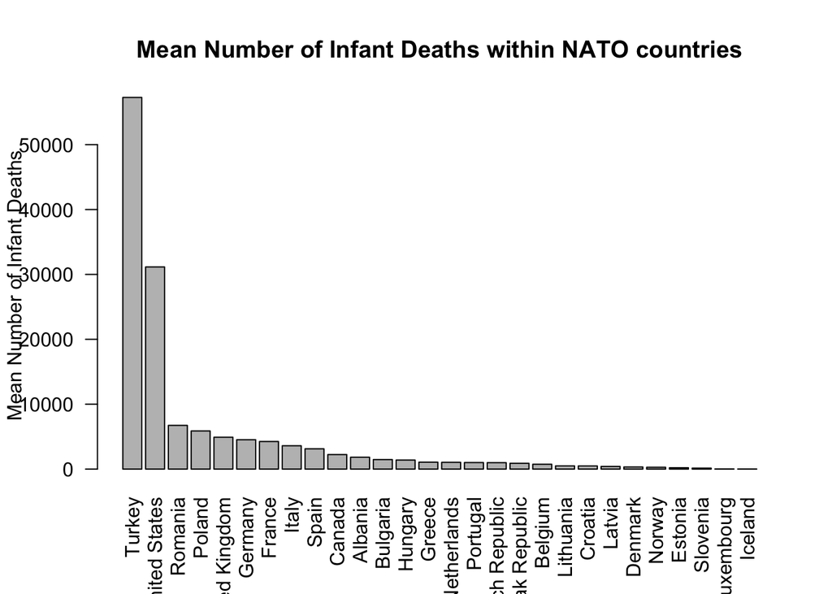

```r
# Simple Horizontal Bar Plot with Added Labels
barplot(final$mean_ind, main="Mean Number of Infant Deaths within NATO countries",
  names.arg=final$country,ylab="Mean Number of Infant Deaths",las=2)
```